# On the estimation of cdf/sf for censored data

Christophe Dutang

26/07/2017

# Non-censored data

Consider observations $x_1,\dots,x_n$ as realizations of random variables $X_1,\dots,X_n$. The empirical cdf is defined as
$$F_n(x) = \frac{1}{n}\sum_{i=1}^n 1_{X_i\leq x}$$
In particular $F_n(x_j)=R_j/n$ where $R_j$ is the rank of the $j$th observation. The empirical survival function is defined as
$$S_n(x) = \frac{1}{n}\sum_{i=1}^n 1_{X_i> x}$$

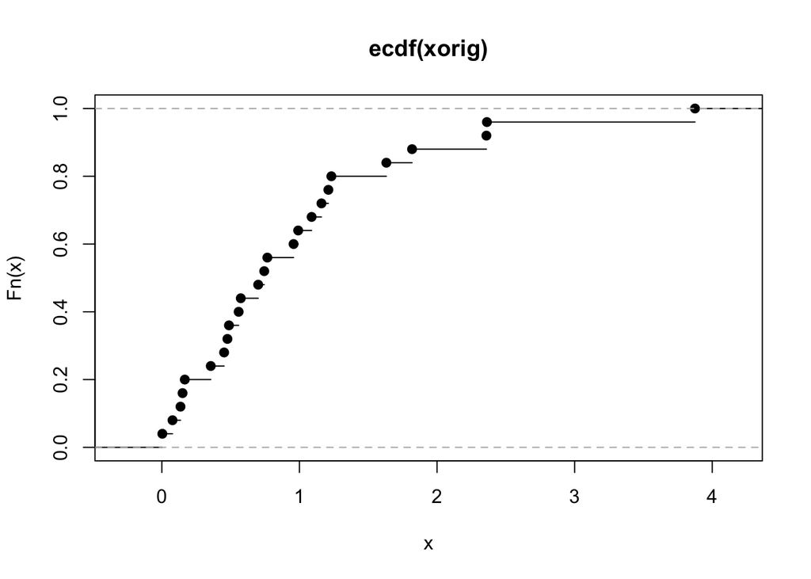

```r
xorig <- rexp(25)
plot(ecdf(xorig))
```

# Right-censored data

Consider observations $t_1,\dots,t_n$ and censoring dummies $d_1,\dots,d_n$ such that
$$d_i=0\Rightarrow t_i = x_i\leq c_i,
d_i=1\Rightarrow t_i = c_i < x_i$$
where $c_i$’s are censored values. In other words, when $d_i=1$, we know that $x_i>c_i$. This can be represented as interval values
$$d_i=0\Rightarrow [t_i,t_i],
d_i=1\Rightarrow (t_i, +\infty).$$
The survival function is estimated (generally) by Kaplan-Meier estimator
$$S_n(x) = \prod_{i, t_i < x} \frac{n_i-d_i}{n_i},$$
where $n_i$ is the number of at-risk individuals at time $t_i$ and $d_i$ the number of non-censored deaths at $t_i$. We get back to usual estimation of previous section if there is no censoring.

Consider a distribution function $F$ with density/mass proba function $f$. The likelihood function to observe $(t_i,d_i)_i$ is
$$L(F,f) = \prod_{i=1}^nf(t_i)^{1-d_i} (1-F(t_i))^{d_i}.$$
Kaplan-Meier is known to maximize this likelihood function and is called sometimes NPMLE, non parametric ML Estimator.

# Left-censored data

Consider observations $t_1,\dots,t_n$ and censoring dummies $d_1,\dots,d_n$ such that
$$d_i=0\Rightarrow t_i = x_i\geq c_i,
d_i=1\Rightarrow t_i = c_i > x_i$$
where $c_i$’s are censored values. In other words, when $d_i=1$, we know that $x_i<c_i$. This can be represented as interval values
$$d_i=0\Rightarrow [t_i,t_i],
d_i=1\Rightarrow (0,t_i).$$

# Interval-censored data

Source: https://www.r-project.org/conferences/useR-2010/tutorials/Fay_1.pdf

Consider observations $(l_i,r_i]$ such that the true observation $x_i$ lies within this interval. If there is no censoring, we observe $[l_i,l_i]$. Right-censoring is obtained with $u_i=\infty$ and left-censoring with $l_i=0$. The likelihood function for cdf $F$ is
$$L(F) = \prod_{i=1}^n(F(r_i)-F(l_i)).$$
Consider $t_0=0<t_1<\dots<t_m<t_{m+1}=\infty$ with $t_1,\dots,t_m$ unique observations times among $l_i,r_i$’s values. We want to estimate $F(t_i)-F(t_{i-1})=p(t_i)$ with observations.

The NPMLE is the Turnbull EM algorithm given below 1. Initialize probability vector estimating $p(t_i)$
$$\widehat{p} =(\widehat{p}_0,\dots,\widehat{p}_{m+1})
= (\frac{1}{m+1},\dots,\frac{1}{m+1})$$
2. Expectation step: Iterate for all $i$, we estimate $P(t_{j-1}<X_i\leq t_j \vert l_i<X_i\leq r_i)$ by
$$\widehat{p}_{i}(t_j) \leftarrow \frac{\widehat{p}_j 1_{t_j \in (l_i,r_i]}}{\sum_{k, t_k \in (l_i,r_i]}\widehat{p}_k}, j=0,\dots,m+1$$
We obtain a vector $\widehat{p}_i$ for all individuals.
3. Maximization step: average over individuals
$$\widehat{p} \leftarrow 1/n \sum_{i=1}^n\widehat{p}_i.$$
4. If not converge, go to step 2.

The estimator of the cdf is the cumsum of $\widehat p$.